# R Notebook

```r
ceodata <- read.csv('ceo.csv')
ceodata$X <- NULL
salary <- ceodata$salary
head(ceodata)
```

|  | salary | totcomp | tenure | age | sales | profits | assets |
| --- | --- | --- | --- | --- | --- | --- | --- |
| 1 | 3030 | 8138 | 7 | 61 | 161315 | 2956 | 257389 |
| 2 | 6050 | 14530 | 0 | 51 | 144416 | 22071 | 237545 |
| 3 | 3571 | 7433 | 11 | 63 | 139208 | 4430 | 49271 |
| 4 | 3300 | 13464 | 6 | 60 | 100697 | 6370 | 92630 |
| 5 | 10000 | 68285 | 18 | 63 | 100469 | 9296 | 355935 |
| 6 | 9375 | 42381 | 6 | 57 | 81667 | 6328 | 86100 |

# 1

### 1.a

```r
mean(salary)
```

```
[1] 2027.517
```

Mean(2027.517) - average salary.

```r
mean.default(salary, trim=0.1)
```

```
[1] 1710.092
```

Trimmed mean(1710.092) - mean of salaries without lowest 10% and highest 10% of values.  
Used to eliminate the impact of vary large or very small salaries on the mean.

```r
median(salary)
```

```
[1] 1600
```

Median(1600) - central salary. Half of salaries are smaller than median and half are larger.

```r
quantile(salary, c(0.25, 0.75))
```

```
   25%    75%
1084.0 2347.5
```

Lower quartile(1084.0) - 25% of salaries are smaller than lower quartile (consequently 75% are larger)  
Upper quartile(2347.5) - 75% of salaries are smaller than upper quartile (consequently 25% are larger)

```r
quantile(salary, c(0.1,0.9))
```

```
   10%    90%
 750.0 3384.4
```

### 1.b

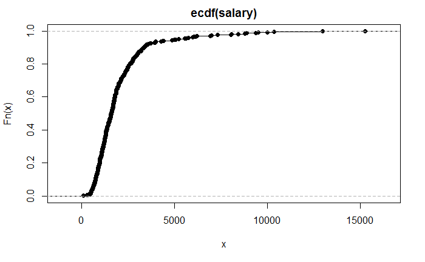

```r
plot(Fn)
```

Empirical cumulative distribution function of salaries

```r
quantile(salary, c(0.2))
```

```
  20%
976.2
```

```r
quantile(salary, c(0.8))
```

```
 80%
2613
```

```r
Fn(1000)
```

```
[1] 0.2237136
```

```r
1 - Fn(5000)
```

```
[1] 0.05369128
```

- $F^{-1}(0.2)=976.2$ - 20% of CEOs have at most $976.2 salary.  
  $F^{-1}(0.8)=2613$ - 80% of CEOs have at most $2613 salary.
- $F(1000)=0.223$ - 22.3% of CEOs have at most $1000 salary.  
  $1 - F(5000)=0.053$ - 5.3% of CEOs have at least $5000 salary.

### 1.c

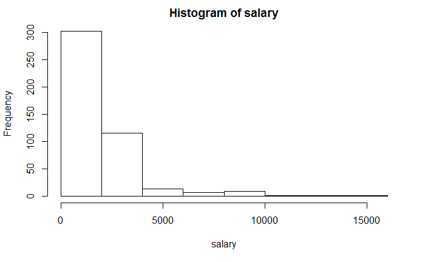

```r
hist(salary)
```

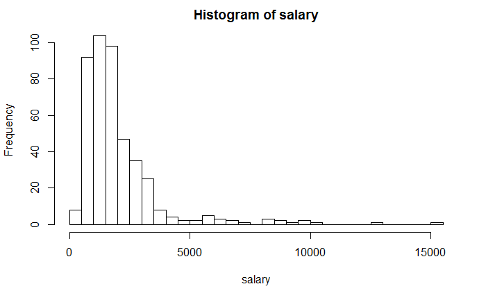

```r
hist(salary, breaks = 30)
```

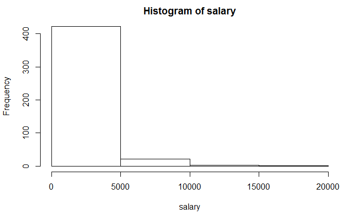

```r
hist(salary, breaks = 3)
```

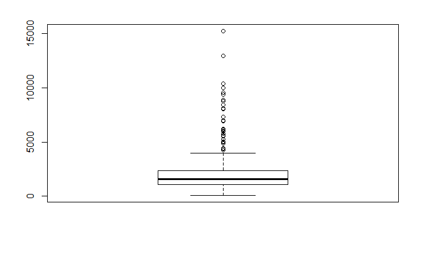

```r
boxplot(salary)
```

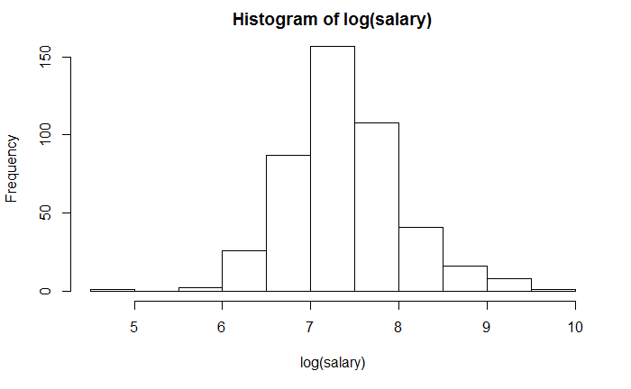

```r
hist(log(salary))
```

```r
mean(log(salary))
```

```
[1] 7.391898
```

```r
median(log(salary))
```

```
[1] 7.377759
```

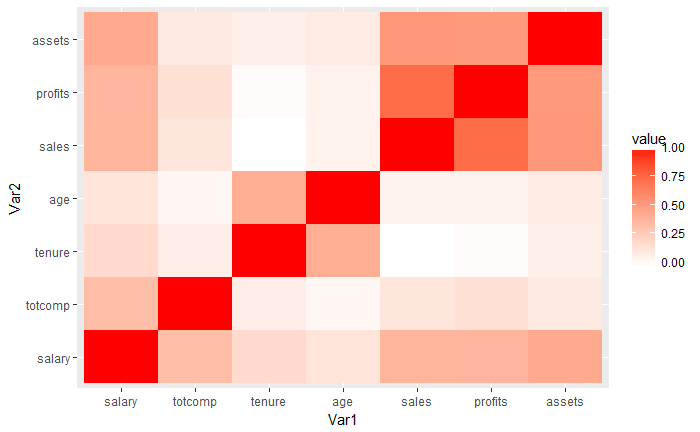

```r
library(ggplot2)
library(reshape2)
qplot(x=Var1, y=Var2, data=melt(cor(ceodata)), fill=value, geom="tile") + scale_fill_gradient(low = "white", high = "red")
```